# pgp-aiml-feb20-CNN_R8_Project_1_Auto_ImgDataset

Requirement - to understand which car/car manufacturer/make of car is popular in certain area of city. So based on image of car -> want to predict which class car belongs to

Solution : - Following fields should be considered to build image dataset when company team takes picture and store on disk system2

1) ImageFilePath - File path of image 2) MakeofCar - Make of Car (Label) 3) Locality - Area of city to which car belongs to To store details of images - above fields can be created in excel sheet or csv file.

Folder Structure - While storing images on the digital storage system, images should be stored in folder having name of make of car. E.g. 'ImageDataSet' is root folder

ImageDataSet -> Maruti -> in this store images of Maruti cars ImageDataSet -> Honda -> in this store images of Honda cars ImageDataSet -> Mahindra -> in this store images of Mahindra cars ...and so on

This storage system will give better control over managing files, loading files in system for model building, the folder name gives idea of make of car (acts as labelling)

With above dataset - an ML model can be build predict make of car once image of car is given. Based on the make of car and possible locations can be fetched. It is possible that one or more make of cars are found in multi locations.

Challenges - 1) While team of brand research company takes picture, they may have to take permission of the owner of cars or local authority from that locality. Sometimes it may happen that people reject the request to take image and need to be convinced about purpose of the activity.

```python
#Lets import image data set and display some of the images along with their label
import os, sys
import numpy as np
import pandas as pd
import matplotlib.pyplot as plt
import seaborn as sns

basefolder = 'C:/Users/amol/Documents/GITRepo/Labfiles/Residency-8/Project-1'
```

```python
folderlst = [f for f in os.listdir(basefolder) if os.path.isdir(os.path.join(basefolder, f))]
folderlst
```

```
['Audi', 'BMW', 'Mercedes', 'Toyota']
```

```python
images =[]
labels =[]
for folder in folderlst :
  i=0
  classFolder = basefolder + '/' + folder
  files = [f for f in os.listdir(classFolder) if os.path.isfile(os.path.join(classFolder, f))]
  for fi in files :
    img = Image.open(classFolder + '/' + fi)
    images.append(img)
    labels.append(folder)
```

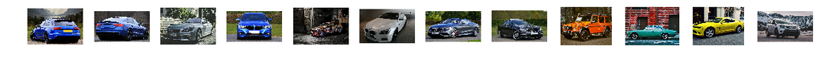

```
Class for each of the above image: ['Audi', 'Audi', 'BMW', 'BMW', 'BMW', 'BMW', 'Mercedes', 'Mercedes', 'Mercedes', 'Mercedes', 'Mercedes']
```

```python
plt.figure(figsize=(20, 1))
for i in range(12):
    plt.subplot(1, 12, i+1)
    plt.imshow(images[i], cmap="gray")
    plt.axis('off')
plt.show()
print('Class for each of the above image: %s' % (labels[0:11]))
```

The images shown above are downloaded from the internet and are not taken pictire from any city.